# Assignment 2: Neural Network

### Prepare the correct language settings for the R-Environment

E.g. german console output may lead to issues. Default should be english.

```r
# Sys.setlocale("LC_ALL","English")
# Sys.setenv(LANG = "en_US.UTF-8")
# Sys.setlocale("LC_MESSAGES", 'en_GB.UTF-8')
#
# ## Check if the settings are correct. It should look like:
# ## [1] "LC_COLLATE=English_United States.1252;LC_CTYPE=English_United States.1252;LC_MONETARY=English_United States.1252;LC_NUMERIC=C;LC_TIME=English_United States.1252"
# Sys.getlocale()
#
```

### Install and Load Libraries

```r
libraries_used <- c("keras", "lime", "tidyquant", "rsample", "recipes", "yardstick", "corrr", "caret")

libraries_missing <- libraries_used[!(libraries_used %in% installed.packages()[,"Package"])]
if(length(libraries_missing)) install.packages(libraries_missing)

# Load libraries
library(keras)
library(lime)
library(tidyquant)
library(rsample)
library(recipes)
library(yardstick)
library(corrr)
library(caret)

set.seed(1)
```

### Load Datasets

```r
train_frame <- read.csv("regression_train_loan.csv")
test_frame <- read.csv("loan_eval.csv")
```

### Get meta information and output it

```r
meta_df <- funModeling::df_status( train_frame, print_results = FALSE )

knitr::kable(meta_df)
```

| variable | q_zeros | p_zeros | q_na | p_na | q_inf | p_inf | type | unique |
| --- | --- | --- | --- | --- | --- | --- | --- | --- |
| X | 0 | 0.00 | 0 | 0.00 | 0 | 0 | integer | 798641 |
| id | 0 | 0.00 | 0 | 0.00 | 0 | 0 | integer | 798641 |
| member_id | 0 | 0.00 | 0 | 0.00 | 0 | 0 | integer | 798641 |
| loan_amnt | 0 | 0.00 | 0 | 0.00 | 0 | 0 | integer | 1372 |
| funded_amnt | 0 | 0.00 | 0 | 0.00 | 0 | 0 | integer | 1372 |
| funded_amnt_inv | 202 | 0.03 | 0 | 0.00 | 0 | 0 | numeric | 9040 |
| term | 0 | 0.00 | 0 | 0.00 | 0 | 0 | character | 2 |
| int_rate | 0 | 0.00 | 0 | 0.00 | 0 | 0 | numeric | 540 |
| installment | 0 | 0.00 | 0 | 0.00 | 0 | 0 | numeric | 66729 |
| grade | 0 | 0.00 | 0 | 0.00 | 0 | 0 | character | 7 |
| sub_grade | 0 | 0.00 | 0 | 0.00 | 0 | 0 | character | 35 |
| emp_title | 0 | 0.00 | 0 | 0.00 | 0 | 0 | character | 274363 |
| emp_length | 0 | 0.00 | 0 | 0.00 | 0 | 0 | character | 12 |
| home_ownership | 0 | 0.00 | 0 | 0.00 | 0 | 0 | character | 6 |
| annual_inc | 2 | 0.00 | 4 | 0.00 | 0 | 0 | numeric | 45904 |
| verification_status | 0 | 0.00 | 0 | 0.00 | 0 | 0 | character | 3 |
| issue_d | 0 | 0.00 | 0 | 0.00 | 0 | 0 | character | 103 |
| loan_status | 0 | 0.00 | 0 | 0.00 | 0 | 0 | character | 10 |
| pymnt_plan | 0 | 0.00 | 0 | 0.00 | 0 | 0 | character | 2 |
| url | 0 | 0.00 | 0 | 0.00 | 0 | 0 | character | 798641 |
| desc | 0 | 0.00 | 0 | 0.00 | 0 | 0 | character | 112107 |
| purpose | 0 | 0.00 | 0 | 0.00 | 0 | 0 | character | 14 |
| title | 0 | 0.00 | 0 | 0.00 | 0 | 0 | character | 57719 |
| zip_code | 0 | 0.00 | 0 | 0.00 | 0 | 0 | character | 931 |
| addr_state | 0 | 0.00 | 0 | 0.00 | 0 | 0 | character | 51 |
| dti | 403 | 0.05 | 0 | 0.00 | 0 | 0 | numeric | 4079 |
| delinq_2yrs | 645151 | 80.78 | 25 | 0.00 | 0 | 0 | integer | 29 |
| earliest_cr_line | 0 | 0.00 | 0 | 0.00 | 0 | 0 | character | 695 |
| inq_last_6mths | 448047 | 56.10 | 25 | 0.00 | 0 | 0 | integer | 25 |
| mths_since_last_delinq | 1526 | 0.19 | 408818 | 51.19 | 0 | 0 | integer | 154 |
| mths_since_last_record | 1144 | 0.14 | 675190 | 84.54 | 0 | 0 | integer | 123 |
| open_acc | 6 | 0.00 | 25 | 0.00 | 0 | 0 | integer | 74 |
| pub_rec | 676301 | 84.68 | 25 | 0.00 | 0 | 0 | integer | 29 |
| revol_bal | 3075 | 0.39 | 0 | 0.00 | 0 | 0 | numeric | 71446 |
| revol_util | 3210 | 0.40 | 454 | 0.06 | 0 | 0 | numeric | 1337 |
| total_acc | 0 | 0.00 | 25 | 0.00 | 0 | 0 | integer | 134 |
| initial_list_status | 0 | 0.00 | 0 | 0.00 | 0 | 0 | character | 2 |
| out_prncp | 230216 | 28.83 | 0 | 0.00 | 0 | 0 | numeric | 229320 |
| out_prncp_inv | 230216 | 28.83 | 0 | 0.00 | 0 | 0 | numeric | 245733 |
| total_pymnt | 15911 | 1.99 | 0 | 0.00 | 0 | 0 | numeric | 465319 |
| total_pymnt_inv | 16155 | 2.02 | 0 | 0.00 | 0 | 0 | numeric | 466355 |
| total_rec_prncp | 16251 | 2.03 | 0 | 0.00 | 0 | 0 | numeric | 241597 |
| total_rec_int | 16311 | 2.04 | 0 | 0.00 | 0 | 0 | numeric | 306708 |
| total_rec_late_fee | 787382 | 98.59 | 0 | 0.00 | 0 | 0 | numeric | 5699 |
| recoveries | 776435 | 97.22 | 0 | 0.00 | 0 | 0 | numeric | 20856 |
| collection_recovery_fee | 777490 | 97.35 | 0 | 0.00 | 0 | 0 | numeric | 18726 |
| last_pymnt_d | 0 | 0.00 | 0 | 0.00 | 0 | 0 | character | 99 |
| last_pymnt_amnt | 15822 | 1.98 | 0 | 0.00 | 0 | 0 | numeric | 215014 |
| next_pymnt_d | 0 | 0.00 | 0 | 0.00 | 0 | 0 | character | 100 |
| last_credit_pull_d | 0 | 0.00 | 0 | 0.00 | 0 | 0 | character | 103 |
| collections_12_mths_ex_med | 787941 | 98.66 | 126 | 0.02 | 0 | 0 | integer | 12 |
| mths_since_last_major_derog | 143 | 0.02 | 599107 | 75.02 | 0 | 0 | integer | 167 |
| policy_code | 0 | 0.00 | 0 | 0.00 | 0 | 0 | integer | 1 |
| application_type | 0 | 0.00 | 0 | 0.00 | 0 | 0 | character | 2 |
| annual_inc_joint | 0 | 0.00 | 798181 | 99.94 | 0 | 0 | numeric | 284 |
| dti_joint | 0 | 0.00 | 798183 | 99.94 | 0 | 0 | numeric | 407 |
| verification_status_joint | 0 | 0.00 | 0 | 0.00 | 0 | 0 | character | 4 |
| acc_now_delinq | 794889 | 99.53 | 25 | 0.00 | 0 | 0 | integer | 8 |
| tot_coll_amt | 630586 | 78.96 | 63276 | 7.92 | 0 | 0 | integer | 9850 |
| tot_cur_bal | 114 | 0.01 | 63276 | 7.92 | 0 | 0 | numeric | 311133 |
| open_acc_6m | 7398 | 0.93 | 779525 | 97.61 | 0 | 0 | integer | 13 |
| open_il_6m | 2098 | 0.26 | 779525 | 97.61 | 0 | 0 | integer | 31 |
| open_il_12m | 9696 | 1.21 | 779525 | 97.61 | 0 | 0 | integer | 12 |
| open_il_24m | 4930 | 0.62 | 779525 | 97.61 | 0 | 0 | integer | 17 |
| mths_since_rcnt_il | 12 | 0.00 | 780030 | 97.67 | 0 | 0 | integer | 200 |
| total_bal_il | 2047 | 0.26 | 779525 | 97.61 | 0 | 0 | integer | 15365 |
| il_util | 122 | 0.02 | 782007 | 97.92 | 0 | 0 | numeric | 1258 |
| open_rv_12m | 6333 | 0.79 | 779525 | 97.61 | 0 | 0 | integer | 17 |
| open_rv_24m | 2543 | 0.32 | 779525 | 97.61 | 0 | 0 | integer | 28 |
| max_bal_bc | 370 | 0.05 | 779525 | 97.61 | 0 | 0 | integer | 10100 |
| all_util | 14 | 0.00 | 779525 | 97.61 | 0 | 0 | numeric | 1119 |
| total_rev_hi_lim | 260 | 0.03 | 63276 | 7.92 | 0 | 0 | numeric | 19717 |
| inq_fi | 10231 | 1.28 | 779525 | 97.61 | 0 | 0 | integer | 17 |
| total_cu_tl | 10277 | 1.29 | 779525 | 97.61 | 0 | 0 | integer | 33 |
| inq_last_12m | 3563 | 0.45 | 779525 | 97.61 | 0 | 0 | integer | 29 |

### Get amount and percentage of unique and output the table

```r
meta_df_percent <- meta_df %>% mutate(uniq_rat = unique / nrow(train_frame))
meta_df_percent %>% select(variable, unique, uniq_rat) %>% mutate(unique = unique, uniq_rat = scales::percent(uniq_rat)) %>% knitr::kable()
```

| variable | unique | uniq_rat |
| --- | --- | --- |
| X | 798641 | 100.00000% |
| id | 798641 | 100.00000% |
| member_id | 798641 | 100.00000% |
| loan_amnt | 1372 | 0.17179% |
| funded_amnt | 1372 | 0.17179% |
| funded_amnt_inv | 9040 | 1.13192% |
| term | 2 | 0.00025% |
| int_rate | 540 | 0.06761% |
| installment | 66729 | 8.35532% |
| grade | 7 | 0.00088% |
| sub_grade | 35 | 0.00438% |
| emp_title | 274363 | 34.35373% |
| emp_length | 12 | 0.00150% |
| home_ownership | 6 | 0.00075% |
| annual_inc | 45904 | 5.74776% |
| verification_status | 3 | 0.00038% |
| issue_d | 103 | 0.01290% |
| loan_status | 10 | 0.00125% |
| pymnt_plan | 2 | 0.00025% |
| url | 798641 | 100.00000% |
| desc | 112107 | 14.03722% |
| purpose | 14 | 0.00175% |
| title | 57719 | 7.22715% |
| zip_code | 931 | 0.11657% |
| addr_state | 51 | 0.00639% |
| dti | 4079 | 0.51074% |
| delinq_2yrs | 29 | 0.00363% |
| earliest_cr_line | 695 | 0.08702% |
| inq_last_6mths | 25 | 0.00313% |
| mths_since_last_delinq | 154 | 0.01928% |
| mths_since_last_record | 123 | 0.01540% |
| open_acc | 74 | 0.00927% |
| pub_rec | 29 | 0.00363% |
| revol_bal | 71446 | 8.94595% |
| revol_util | 1337 | 0.16741% |
| total_acc | 134 | 0.01678% |
| initial_list_status | 2 | 0.00025% |
| out_prncp | 229320 | 28.71378% |
| out_prncp_inv | 245733 | 30.76889% |
| total_pymnt | 465319 | 58.26385% |
| total_pymnt_inv | 466355 | 58.39357% |
| total_rec_prncp | 241597 | 30.25101% |
| total_rec_int | 306708 | 38.40374% |
| total_rec_late_fee | 5699 | 0.71359% |
| recoveries | 20856 | 2.61144% |
| collection_recovery_fee | 18726 | 2.34473% |
| last_pymnt_d | 99 | 0.01240% |
| last_pymnt_amnt | 215014 | 26.92248% |
| next_pymnt_d | 100 | 0.01252% |
| last_credit_pull_d | 103 | 0.01290% |
| collections_12_mths_ex_med | 12 | 0.00150% |
| mths_since_last_major_derog | 167 | 0.02091% |
| policy_code | 1 | 0.00013% |
| application_type | 2 | 0.00025% |
| annual_inc_joint | 284 | 0.03556% |
| dti_joint | 407 | 0.05096% |
| verification_status_joint | 4 | 0.00050% |
| acc_now_delinq | 8 | 0.00100% |
| tot_coll_amt | 9850 | 1.23335% |
| tot_cur_bal | 311133 | 38.95780% |
| open_acc_6m | 13 | 0.00163% |
| open_il_6m | 31 | 0.00388% |
| open_il_12m | 12 | 0.00150% |
| open_il_24m | 17 | 0.00213% |
| mths_since_rcnt_il | 200 | 0.02504% |
| total_bal_il | 15365 | 1.92389% |
| il_util | 1258 | 0.15752% |
| open_rv_12m | 17 | 0.00213% |
| open_rv_24m | 28 | 0.00351% |
| max_bal_bc | 10100 | 1.26465% |
| all_util | 1119 | 0.14011% |
| total_rev_hi_lim | 19717 | 2.46882% |
| inq_fi | 17 | 0.00213% |
| total_cu_tl | 33 | 0.00413% |
| inq_last_12m | 29 | 0.00363% |

### Output a table with amount of unique, N/A, and zero values

```r
meta_df %>% select(variable, p_zeros, p_na, unique) %>% knitr::kable()
```

| variable | p_zeros | p_na | unique |
| --- | --- | --- | --- |
| X | 0.00 | 0.00 | 798641 |
| id | 0.00 | 0.00 | 798641 |
| member_id | 0.00 | 0.00 | 798641 |
| loan_amnt | 0.00 | 0.00 | 1372 |
| funded_amnt | 0.00 | 0.00 | 1372 |
| funded_amnt_inv | 0.03 | 0.00 | 9040 |
| term | 0.00 | 0.00 | 2 |
| int_rate | 0.00 | 0.00 | 540 |
| installment | 0.00 | 0.00 | 66729 |
| grade | 0.00 | 0.00 | 7 |
| sub_grade | 0.00 | 0.00 | 35 |
| emp_title | 0.00 | 0.00 | 274363 |
| emp_length | 0.00 | 0.00 | 12 |
| home_ownership | 0.00 | 0.00 | 6 |
| annual_inc | 0.00 | 0.00 | 45904 |
| verification_status | 0.00 | 0.00 | 3 |
| issue_d | 0.00 | 0.00 | 103 |
| loan_status | 0.00 | 0.00 | 10 |
| pymnt_plan | 0.00 | 0.00 | 2 |
| url | 0.00 | 0.00 | 798641 |
| desc | 0.00 | 0.00 | 112107 |
| purpose | 0.00 | 0.00 | 14 |
| title | 0.00 | 0.00 | 57719 |
| zip_code | 0.00 | 0.00 | 931 |
| addr_state | 0.00 | 0.00 | 51 |
| dti | 0.05 | 0.00 | 4079 |
| delinq_2yrs | 80.78 | 0.00 | 29 |
| earliest_cr_line | 0.00 | 0.00 | 695 |
| inq_last_6mths | 56.10 | 0.00 | 25 |
| mths_since_last_delinq | 0.19 | 51.19 | 154 |
| mths_since_last_record | 0.14 | 84.54 | 123 |
| open_acc | 0.00 | 0.00 | 74 |
| pub_rec | 84.68 | 0.00 | 29 |
| revol_bal | 0.39 | 0.00 | 71446 |
| revol_util | 0.40 | 0.06 | 1337 |
| total_acc | 0.00 | 0.00 | 134 |
| initial_list_status | 0.00 | 0.00 | 2 |
| out_prncp | 28.83 | 0.00 | 229320 |
| out_prncp_inv | 28.83 | 0.00 | 245733 |
| total_pymnt | 1.99 | 0.00 | 465319 |
| total_pymnt_inv | 2.02 | 0.00 | 466355 |
| total_rec_prncp | 2.03 | 0.00 | 241597 |
| total_rec_int | 2.04 | 0.00 | 306708 |
| total_rec_late_fee | 98.59 | 0.00 | 5699 |
| recoveries | 97.22 | 0.00 | 20856 |
| collection_recovery_fee | 97.35 | 0.00 | 18726 |
| last_pymnt_d | 0.00 | 0.00 | 99 |
| last_pymnt_amnt | 1.98 | 0.00 | 215014 |
| next_pymnt_d | 0.00 | 0.00 | 100 |
| last_credit_pull_d | 0.00 | 0.00 | 103 |
| collections_12_mths_ex_med | 98.66 | 0.02 | 12 |
| mths_since_last_major_derog | 0.02 | 75.02 | 167 |
| policy_code | 0.00 | 0.00 | 1 |
| application_type | 0.00 | 0.00 | 2 |
| annual_inc_joint | 0.00 | 99.94 | 284 |
| dti_joint | 0.00 | 99.94 | 407 |
| verification_status_joint | 0.00 | 0.00 | 4 |
| acc_now_delinq | 99.53 | 0.00 | 8 |
| tot_coll_amt | 78.96 | 7.92 | 9850 |
| tot_cur_bal | 0.01 | 7.92 | 311133 |
| open_acc_6m | 0.93 | 97.61 | 13 |
| open_il_6m | 0.26 | 97.61 | 31 |
| open_il_12m | 1.21 | 97.61 | 12 |
| open_il_24m | 0.62 | 97.61 | 17 |
| mths_since_rcnt_il | 0.00 | 97.67 | 200 |
| total_bal_il | 0.26 | 97.61 | 15365 |
| il_util | 0.02 | 97.92 | 1258 |
| open_rv_12m | 0.79 | 97.61 | 17 |
| open_rv_24m | 0.32 | 97.61 | 28 |
| max_bal_bc | 0.05 | 97.61 | 10100 |
| all_util | 0.00 | 97.61 | 1119 |
| total_rev_hi_lim | 0.03 | 7.92 | 19717 |
| inq_fi | 1.28 | 97.61 | 17 |
| total_cu_tl | 1.29 | 97.61 | 33 |
| inq_last_12m | 0.45 | 97.61 | 29 |

### Remove columns deemed unfit for modeling

```r
vars_to_remove <- c("annual_inc_joint", "dti_joint", "policy_code", "id", "member_id",
                    "emp_title", "url", "desc", "title", "open_acc_6m", "open_il_6m",
                    "open_il_12m", "open_il_24m", "mths_since_rcnt_il", "total_bal_il",
                    "il_util", "open_rv_12m", "open_rv_24m", "max_bal_bc", "all_util",
                    "total_rev_hi_lim", "inq_fi", "total_cu_tl", "inq_last_12m",
                    "verification_status_joint", "next_pymnt_d", "sub_grade", "X", "zip_code", "application_type")

train_frame <- train_frame %>% select(-one_of(vars_to_remove))
test_frame <- test_frame %>% select(-one_of(vars_to_remove))
```

### Convert date attributes

```r
chr_to_date_vars <-  c("issue_d", "last_pymnt_d", "last_credit_pull_d", "earliest_cr_line")
convert_date <- function(x){
  as.Date(paste0("01-", x), format = "%d-%b-%Y")
}

train_frame <- train_frame %>% mutate_at(.funs = list(convert_date), .vars = chr_to_date_vars)
test_frame <- test_frame %>% mutate_at(.funs = list(convert_date), .vars = chr_to_date_vars)
```

### Output numerical vars

```r
num_vars <-  train_frame %>%  sapply(is.numeric) %>%  which() %>% names()

meta_df <- funModeling::df_status(train_frame, print_results = FALSE) %>%
  select(variable, p_zeros, p_na, unique) %>%
  filter_(~ variable %in% num_vars) %>%
  knitr::kable()
```

### Correlation plot

First step to get an overview of potential collinearities. Failing to identify multicollinearity could result in misleading interpretations of the results.

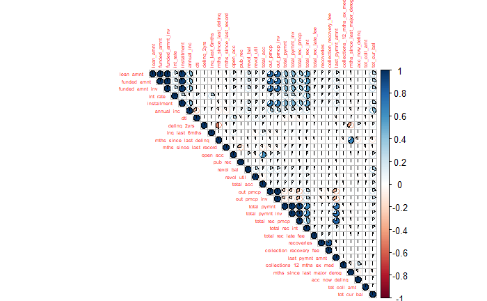

```r
corrplot::corrplot(cor(train_frame[, num_vars], use = "complete.obs"),
                   method = "pie", type = "upper",tl.cex = 0.45)
```

### Recreate meta table

```r
meta_df <- funModeling::df_status( train_frame, print_results = FALSE )
meta_df %>% select(variable, p_zeros, p_na, unique) %>% knitr::kable()
```

| variable | p_zeros | p_na | unique |
| --- | --- | --- | --- |
| loan_amnt | 0.00 | 0.00 | 1372 |
| funded_amnt | 0.00 | 0.00 | 1372 |
| funded_amnt_inv | 0.03 | 0.00 | 9040 |
| term | 0.00 | 0.00 | 2 |
| int_rate | 0.00 | 0.00 | 540 |
| installment | 0.00 | 0.00 | 66729 |
| grade | 0.00 | 0.00 | 7 |
| emp_length | 0.00 | 0.00 | 12 |
| home_ownership | 0.00 | 0.00 | 6 |
| annual_inc | 0.00 | 0.00 | 45904 |
| verification_status | 0.00 | 0.00 | 3 |
| issue_d | 0.00 | 0.00 | 103 |
| loan_status | 0.00 | 0.00 | 10 |
| pymnt_plan | 0.00 | 0.00 | 2 |
| purpose | 0.00 | 0.00 | 14 |
| addr_state | 0.00 | 0.00 | 51 |
| dti | 0.05 | 0.00 | 4079 |
| delinq_2yrs | 80.78 | 0.00 | 29 |
| earliest_cr_line | 0.01 | 0.00 | 694 |
| inq_last_6mths | 56.10 | 0.00 | 25 |
| mths_since_last_delinq | 0.19 | 51.19 | 154 |
| mths_since_last_record | 0.14 | 84.54 | 123 |
| open_acc | 0.00 | 0.00 | 74 |
| pub_rec | 84.68 | 0.00 | 29 |
| revol_bal | 0.39 | 0.00 | 71446 |
| revol_util | 0.40 | 0.06 | 1337 |
| total_acc | 0.00 | 0.00 | 134 |
| initial_list_status | 0.00 | 0.00 | 2 |
| out_prncp | 28.83 | 0.00 | 229320 |
| out_prncp_inv | 28.83 | 0.00 | 245733 |
| total_pymnt | 1.99 | 0.00 | 465319 |
| total_pymnt_inv | 2.02 | 0.00 | 466355 |
| total_rec_prncp | 2.03 | 0.00 | 241597 |
| total_rec_int | 2.04 | 0.00 | 306708 |
| total_rec_late_fee | 98.59 | 0.00 | 5699 |
| recoveries | 97.22 | 0.00 | 20856 |
| collection_recovery_fee | 97.35 | 0.00 | 18726 |
| last_pymnt_d | 0.00 | 1.98 | 98 |
| last_pymnt_amnt | 1.98 | 0.00 | 215014 |
| last_credit_pull_d | 0.00 | 0.01 | 102 |
| collections_12_mths_ex_med | 98.66 | 0.02 | 12 |
| mths_since_last_major_derog | 0.02 | 75.02 | 167 |
| acc_now_delinq | 99.53 | 0.00 | 8 |
| tot_coll_amt | 78.96 | 7.92 | 9850 |
| tot_cur_bal | 0.01 | 7.92 | 311133 |

### Display highly correlated variables

We want to identify collinearities which could affect our regression model. A Cut-off at 0.8 is applied as suggest by Berry & Feldman, 1985: Multiple Regression in Practice (Quantitative Applications in the Social Sciences)

```r
caret::findCorrelation(cor(train_frame[, num_vars], use = "complete.obs"), names = TRUE, cutoff = .8)
```

```
[1] "loan_amnt"               "funded_amnt"             "funded_amnt_inv"         "total_pymnt_inv"         "total_pymnt"
[6] "out_prncp"               "total_rec_prncp"         "collection_recovery_fee"
```

### Remove highly correlated variables to avoid the interference of collinearity in our model

Multicollinearity arises when at least two highly correlated predictors are assessed simultaneously in a regression model.

```r
vars_to_remove <-
  c("loan_amnt", "funded_amnt", "funded_amnt_inv", "total_pymnt",
    "total_pymnt_inv", "out_prncp", "collection_recovery_fee")

train_frame <- train_frame %>% select(-one_of(vars_to_remove))
test_frame <- test_frame %>% select(-one_of(vars_to_remove))
```

### Recreate meta table

```r
meta_df <- funModeling::df_status( train_frame, print_results = FALSE )
meta_df %>% select(variable, p_zeros, p_na, unique) %>% knitr::kable()
```

| variable | p_zeros | p_na | unique |
| --- | --- | --- | --- |
| term | 0.00 | 0.00 | 2 |
| int_rate | 0.00 | 0.00 | 540 |
| installment | 0.00 | 0.00 | 66729 |
| grade | 0.00 | 0.00 | 7 |
| emp_length | 0.00 | 0.00 | 12 |
| home_ownership | 0.00 | 0.00 | 6 |
| annual_inc | 0.00 | 0.00 | 45904 |
| verification_status | 0.00 | 0.00 | 3 |
| issue_d | 0.00 | 0.00 | 103 |
| loan_status | 0.00 | 0.00 | 10 |
| pymnt_plan | 0.00 | 0.00 | 2 |
| purpose | 0.00 | 0.00 | 14 |
| addr_state | 0.00 | 0.00 | 51 |
| dti | 0.05 | 0.00 | 4079 |
| delinq_2yrs | 80.78 | 0.00 | 29 |
| earliest_cr_line | 0.01 | 0.00 | 694 |
| inq_last_6mths | 56.10 | 0.00 | 25 |
| mths_since_last_delinq | 0.19 | 51.19 | 154 |
| mths_since_last_record | 0.14 | 84.54 | 123 |
| open_acc | 0.00 | 0.00 | 74 |
| pub_rec | 84.68 | 0.00 | 29 |
| revol_bal | 0.39 | 0.00 | 71446 |
| revol_util | 0.40 | 0.06 | 1337 |
| total_acc | 0.00 | 0.00 | 134 |
| initial_list_status | 0.00 | 0.00 | 2 |
| out_prncp_inv | 28.83 | 0.00 | 245733 |
| total_rec_prncp | 2.03 | 0.00 | 241597 |
| total_rec_int | 2.04 | 0.00 | 306708 |
| total_rec_late_fee | 98.59 | 0.00 | 5699 |
| recoveries | 97.22 | 0.00 | 20856 |
| last_pymnt_d | 0.00 | 1.98 | 98 |
| last_pymnt_amnt | 1.98 | 0.00 | 215014 |
| last_credit_pull_d | 0.00 | 0.01 | 102 |
| collections_12_mths_ex_med | 98.66 | 0.02 | 12 |
| mths_since_last_major_derog | 0.02 | 75.02 | 167 |
| acc_now_delinq | 99.53 | 0.00 | 8 |
| tot_coll_amt | 78.96 | 7.92 | 9850 |
| tot_cur_bal | 0.01 | 7.92 | 311133 |

### Set vars from N/A to zero

```r
na_to_zero_vars <- c("mths_since_last_delinq", "mths_since_last_record", "mths_since_last_major_derog")

train_frame <- train_frame %>% mutate_at(.vars = na_to_zero_vars, .funs = funs(replace(., is.na(.), 0)))
test_frame <- test_frame %>% mutate_at(.vars = na_to_zero_vars, .funs = funs(replace(., is.na(.), 0)))
```

### Set vars from N/A to -99

```r
na_to_negative_ninety_nine <- c("revol_util", "collections_12_mths_ex_med", "tot_coll_amt", "tot_cur_bal")

train_frame <- train_frame %>% mutate_at(.vars = na_to_negative_ninety_nine, .funs = funs(replace(., is.na(.), -99)))
test_frame <- test_frame %>% mutate_at(.vars = na_to_negative_ninety_nine, .funs = funs(replace(., is.na(.), -99)))
```

### Remove rows where date columns contain N/A values

```r
train_frame <- train_frame[complete.cases(train_frame), ]
test_frame <- test_frame[complete.cases(test_frame), ]
```

### Remove all rows where loan status is “Current” + rename all loan_status fields where the value is not “Fully Paid”

```r
train_frame <- subset(train_frame, loan_status != "Current")
train_frame$loan_status[train_frame$loan_status != "Fully Paid"] <- "DEFAULTED"

test_frame <- subset(test_frame, loan_status != "Current")
test_frame$loan_status[test_frame$loan_status != "Fully Paid"] <- "DEFAULTED"
```

### Convert “term” column to number

```r
train_frame$term <- as.numeric(gsub( ".*([0-9]+).*", "\\1", train_frame$term ))

test_frame$term <- as.numeric(gsub( ".*([0-9]+).*", "\\1", test_frame$term ))
```

### Convert “emp_length” to numeric values

```r
train_frame$emp_length[train_frame$emp_length == "n/a"] <- 99
train_frame$emp_length[train_frame$emp_length == "< 1 year"] <- 0
train_frame$emp_length <- as.numeric(gsub( "([0-9]+).*", "\\1", train_frame$emp_length ))

test_frame$emp_length[test_frame$emp_length == "n/a"] <- 99
test_frame$emp_length[test_frame$emp_length == "< 1 year"] <- 0
test_frame$emp_length <- as.numeric(gsub( "([0-9]+).*", "\\1", test_frame$emp_length ))
```

### Data preprocessing

The following steps are executed:

```r
recipe_obj <- recipe( loan_status ~ ., data = train_frame ) %>%
  step_nzv(all_predictors()) %>%
  step_date( has_type( match = "date" ) ) %>%
  step_rm( has_type( match = "date" ) ) %>%
  step_dummy( all_nominal(), -all_outcomes() ) %>%
  step_normalize( all_numeric(), -all_outcomes() ) %>%
  step_scale( all_numeric(), -all_outcomes() ) %>%
  step_center(all_predictors()) %>%
  prep()

x_train_tbl <- bake(recipe_obj, new_data = train_frame) %>% select(-loan_status)
x_test_tbl <- bake(recipe_obj, new_data = test_frame) %>% select(-loan_status)

y_train_vec <- ifelse(pull(train_frame, loan_status) == "DEFAULTED", 1, 0)
y_test_vec <- ifelse(pull(test_frame, loan_status) == "DEFAULTED", 1, 0)
```

### Build the neural network

```r
# Building our Artificial Neural Network
model_keras <- keras_model_sequential() %>%

  # First hidden layer
  layer_dense(
    units              = 16,
    kernel_initializer = "uniform",
    activation         = "relu",
    input_shape        = ncol(x_train_tbl)) %>%

  # Dropout to prevent overfitting
  layer_dropout(rate = 0.1) %>%

  # Second hidden layer
  layer_dense(
    units              = 16,
    kernel_initializer = "uniform",
    activation         = "relu") %>%

  # Dropout to prevent overfitting
  layer_dropout(rate = 0.1) %>%

  # Output layer
  layer_dense(
    units              = 1,
    kernel_initializer = "uniform",
    activation         = "sigmoid") %>%

  # Compile ANN
  compile(
    optimizer = 'adam',
    loss      = 'binary_crossentropy',
    metrics   = c('accuracy')
  )

model_keras
```

```
Model
Model: "sequential_2"
_____________________________________________________________________________________________________________________________________________________
Layer (type)                                                       Output Shape                                               Param #
=====================================================================================================================================================
dense_8 (Dense)                                                    (None, 16)                                                 2688
_____________________________________________________________________________________________________________________________________________________
dropout_5 (Dropout)                                                (None, 16)                                                 0
_____________________________________________________________________________________________________________________________________________________
dense_7 (Dense)                                                    (None, 16)                                                 272
_____________________________________________________________________________________________________________________________________________________
dropout_4 (Dropout)                                                (None, 16)                                                 0
_____________________________________________________________________________________________________________________________________________________
dense_6 (Dense)                                                    (None, 1)                                                  17
=====================================================================================================================================================
Total params: 2,977
Trainable params: 2,977
Non-trainable params: 0
_____________________________________________________________________________________________________________________________________________________
```

### Fit the neural network with the training data

```r
# Fit the keras model to the training data
history <- fit(
  object           = model_keras,
  x                = as.matrix(x_train_tbl),
  y                = y_train_vec,
  batch_size       = 50,
  epochs           = 35,
  validation_split = 0.30
)
```

```
Final epoch (plot to see history):
        loss: 0.03299
    accuracy: 0.9897
    val_loss: 0.02812
val_accuracy: 0.9907
```

### Plot the results of the training

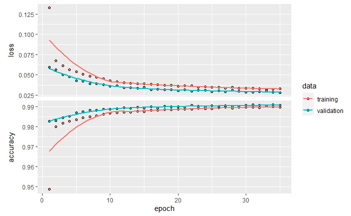

```r
plot(history)
```

### Validate the model using the test data (output estimates)

```r
# Format test data and predictions for yardstick metrics
estimates_keras_tbl <- tibble(
  truth      = as.factor(y_test_vec) %>% forcats::fct_recode(yes = "1", no = "0"),
  estimate   = as.factor(yhat_keras_class_vec) %>% forcats::fct_recode(yes = "1", no = "0"),
  class_prob = yhat_keras_prob_vec
)

estimates_keras_tbl
```

[output not shown]

| truth | estimate | class_prob |
| --- | --- | --- |
| yes | yes | 9.999893e-01 |
| no | no | 1.494855e-02 |
| no | no | 9.825975e-03 |
| no | no | 1.166582e-03 |
| yes | no | 7.985133e-02 |
| no | no | 7.901341e-03 |
| yes | yes | 9.999893e-01 |
| no | no | 1.372308e-03 |
| no | no | 9.675324e-04 |
| no | no | 2.210703e-05 |

[output cut: 990 more lines]

### Confusion Matrix

```r
options(yardstick.event_first = FALSE)

estimates_keras_tbl %>% conf_mat(truth, estimate)
```

```
          Truth
Prediction    no   yes
       no  20793   216
       yes    43  6588
```

### Accuracy

```r
# Accuracy
estimates_keras_tbl %>% metrics(truth, estimate)
```

| .metric | .estimator | .estimate |
| --- | --- | --- |
| accuracy | binary | 0.9906295 |
| kap | binary | 0.9745338 |

### AUC

```r
# AUC
estimates_keras_tbl %>% roc_auc(truth, class_prob)
```

```
The `yardstick.event_first` option has been deprecated as of yardstick 0.0.7 and will be completely ignored in a future version.
Instead, set the following argument directly in the metric function:
`options(yardstick.event_first = TRUE)`  -> `event_level = 'first'` (the default)
```

| .metric | .estimator | .estimate |
| --- | --- | --- |
| roc_auc | binary | 0.9978917 |

### F1-Statistic

```r
# F1-Statistic
estimates_keras_tbl %>% f_meas(truth, estimate, beta = 1)
```

| .metric | .estimator | .estimate |
| --- | --- | --- |
| f_meas | binary | 0.980722 |

### Export the required data to the filesystem

```r
keras::save_model_hdf5(model_keras, "network.nn")
write.csv(x_train_tbl, "nn_train.csv", row.names = TRUE)
write.csv(x_test_tbl, "nn_test.csv", row.names = TRUE)
```